# Exploratory Analysis

## Problems:

Load the NYC AirBnB Truncated Dataset. This dataset is a mirror of the full NYC AirBnB dataset found at Kaggle, but only contains the first 10,000 entries.

https://www.kaggle.com/dgomonov/new-york-city-airbnb-open-data

For the numerical features,

1. Display histograms for the numerical features.
2. Construct the scatter plots of price with each of the numerical features.
3. Display the correlation histogram.
4. Which numerical feature appears to be most predictive of the price?
5. Using numerical features to predict the renting price with linear model. Write down the predict function.
6. Calculate the RSS cost.

```python
import numpy as np
import pandas as pd
from matplotlib import pyplot as plt
from sklearn.model_selection import train_test_split
from sklearn.linear_model import LinearRegression
from sklearn.metrics import mean_squared_error

data = pd.read_csv("https://raw.githubusercontent.com/tipthederiver/Math-7243-2020/master/Datasets/NYCAirBnB/train.csv")
data
```

|  | name | host_id | host_name | neighbourhood_group | neighbourhood | latitude | longitude | room_type | price | minimum_nights | number_of_reviews | last_review | reviews_per_month | calculated_host_listings_count | availability_365 |
| --- | --- | --- | --- | --- | --- | --- | --- | --- | --- | --- | --- | --- | --- | --- | --- |
| 0 | Clean & quiet apt home by the park | 2787 | John | Brooklyn | Kensington | 40.64749 | -73.97237 | Private room | 149 | 1 | 9 | 10/19/2018 | 0.21 | 6 | 365 |
| 1 | Skylit Midtown Castle | 2845 | Jennifer | Manhattan | Midtown | 40.75362 | -73.98377 | Entire home/apt | 225 | 1 | 45 | 5/21/2019 | 0.38 | 2 | 355 |
| 2 | THE VILLAGE OF HARLEM....NEW YORK ! | 4632 | Elisabeth | Manhattan | Harlem | 40.80902 | -73.94190 | Private room | 150 | 3 | 0 | NaN | NaN | 1 | 365 |
| 3 | Cozy Entire Floor of Brownstone | 4869 | LisaRoxanne | Brooklyn | Clinton Hill | 40.68514 | -73.95976 | Entire home/apt | 89 | 1 | 270 | 7/5/2019 | 4.64 | 1 | 194 |
| 4 | Entire Apt: Spacious Studio/Loft by central park | 7192 | Laura | Manhattan | East Harlem | 40.79851 | -73.94399 | Entire home/apt | 80 | 10 | 9 | 11/19/2018 | 0.10 | 1 | 0 |
| ... | ... | ... | ... | ... | ... | ... | ... | ... | ... | ... | ... | ... | ... | ... | ... |
| 9994 | Cozy apt in heart of the e village | 40076332 | Steven | Manhattan | East Village | 40.72644 | -73.98403 | Entire home/apt | 175 | 5 | 0 | NaN | NaN | 1 | 0 |
| 9995 | Perfect Location - Meticulously Kept Flat | 12620454 | Will | Brooklyn | Bushwick | 40.70442 | -73.92484 | Entire home/apt | 220 | 5 | 27 | 1/1/2017 | 0.57 | 1 | 0 |
| 9996 | Garden Apt in Historic Brownstone! | 2060383 | Lisa | Brooklyn | Cobble Hill | 40.68732 | -73.99245 | Entire home/apt | 147 | 3 | 23 | 6/16/2019 | 0.51 | 1 | 2 |
| 9997 | East Village Private Room & Terrace | 39956905 | Can | Manhattan | East Village | 40.72811 | -73.98453 | Private room | 95 | 2 | 1 | 8/29/2015 | 0.02 | 2 | 0 |
| 9998 | Cosy apartment in Carroll Gardens | 33064750 | Suzan | Brooklyn | Carroll Gardens | 40.68282 | -73.99774 | Entire home/apt | 160 | 5 | 2 | 8/8/2017 | 0.06 | 1 | 0 |

9999 rows × 15 columns

### Problem 1

This problem does not specify which numerical property should I use, so I will focus on the price section. And since there're almost 10000 lines of data, we couldn't simply draw diagrams based on that. We will group them

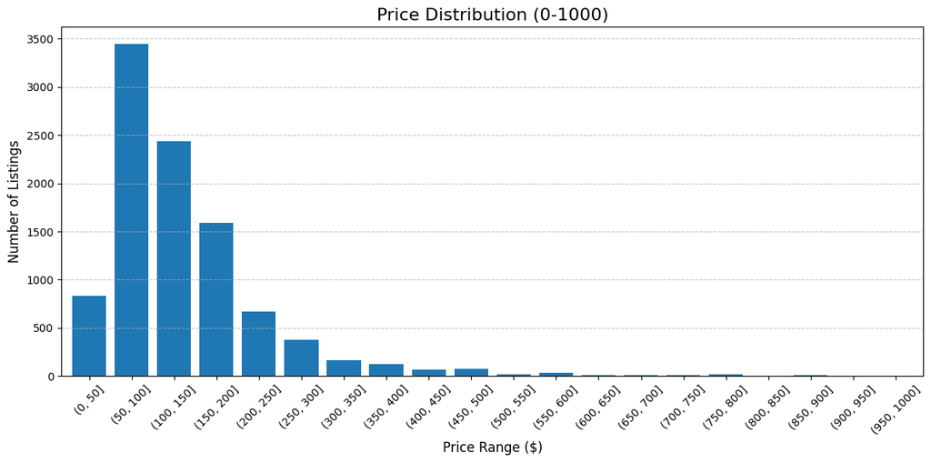

```python
#Problem 1
price_filtered = data[data['price'] < 1000]
bins = range(0, 1050, 50)
price_filtered['price_bin'] = pd.cut(price_filtered['price'], bins=bins)

price_distribution = price_filtered['price_bin'].value_counts().sort_index()

plt.figure(figsize=(12, 6))
price_distribution.plot(kind='bar', width=0.8)
plt.title('Price Distribution (0-1000)', fontsize=16)
plt.xlabel('Price Range ($)', fontsize=12)
plt.ylabel('Number of Listings', fontsize=12)
plt.xticks(rotation=45)
plt.grid(axis='y', linestyle='--', alpha=0.7)
plt.tight_layout()
```

### Problem 2

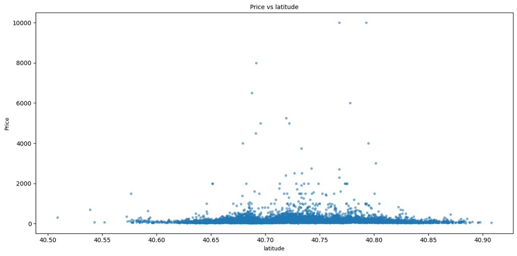

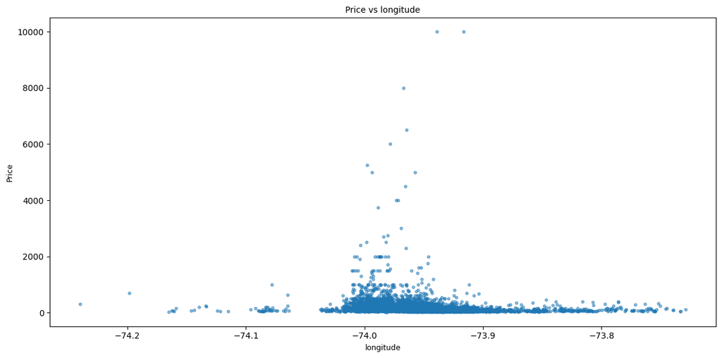

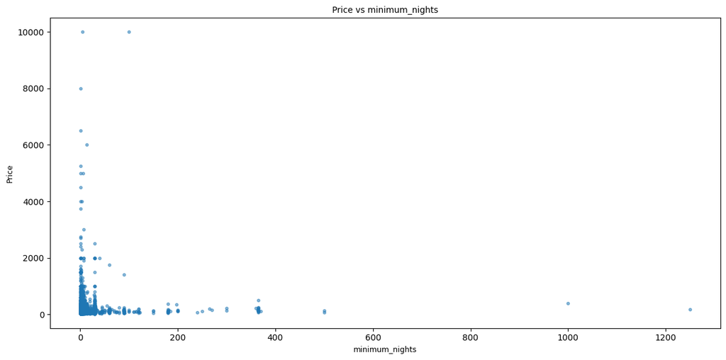

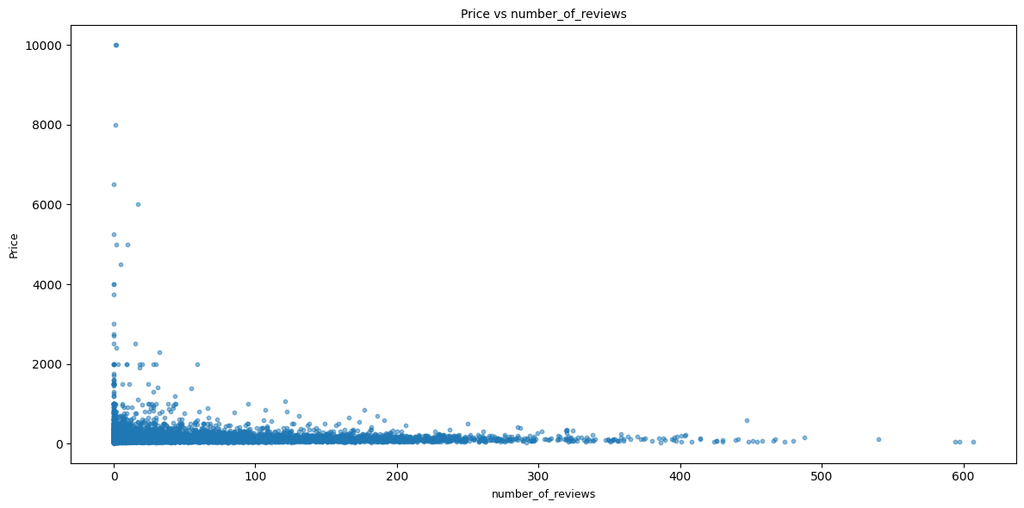

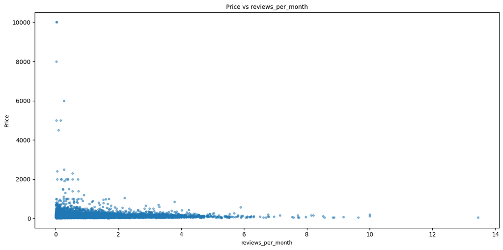

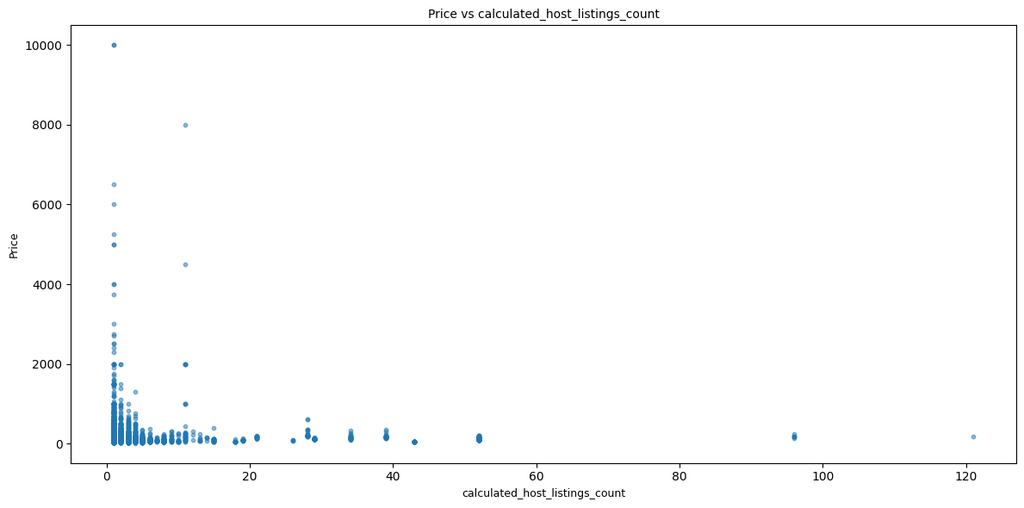

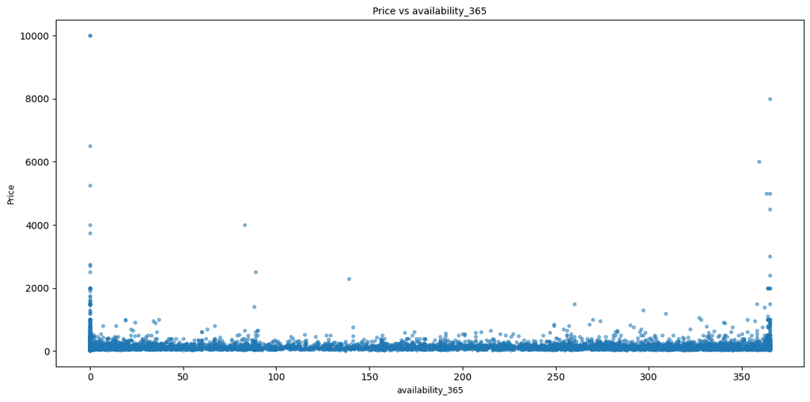

```python
#Problem 2
numerical_features = ["latitude", "longitude", "minimum_nights","number_of_reviews","reviews_per_month","calculated_host_listings_count","availability_365",]
for features in numerical_features:
    plt.figure(figsize=(12, 6))
    plt.scatter(data[features], data["price"], alpha=0.5, s=10)
    plt.title(f"Price vs {features}", fontsize = 10)
    plt.xlabel(features, fontsize=9)
    plt.ylabel("Price", fontsize=9)
    plt.tight_layout()
plt.show()
```

### Problem 3

```
<function matplotlib.pyplot.show(close=None, block=None)>
```

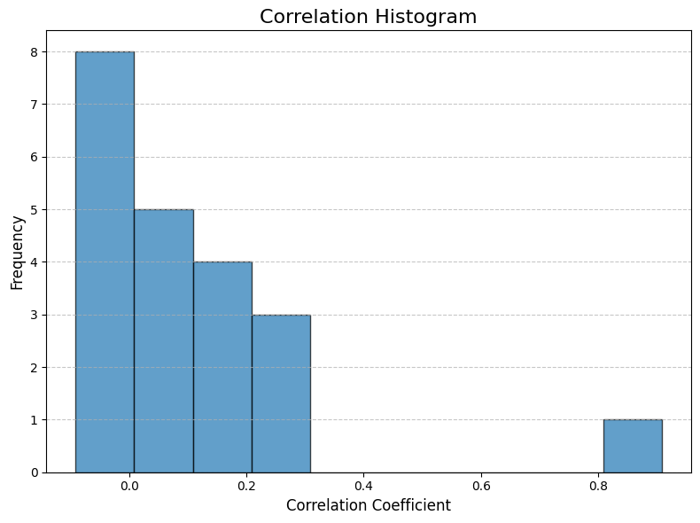

```python
#Problem 3
correlation_matrix = data[numerical_features].corr()
correlation_values = correlation_matrix.values[np.triu_indices_from(correlation_matrix, k=1)]

plt.figure(figsize=(8, 6))
plt.hist(correlation_values, bins=10, edgecolor='black', alpha=0.7)
plt.title('Correlation Histogram', fontsize=16)
plt.xlabel('Correlation Coefficient', fontsize=12)
plt.ylabel('Frequency', fontsize=12)
plt.grid(axis='y', linestyle='--', alpha=0.7)
plt.tight_layout()

plt.show
```

### Problem 4

```python
correlation_with_price = data[numerical_features].corrwith(data["price"]).sort_values(ascending=False)
print("Correlation with price:\n", correlation_with_price)

most_predictive_feature = correlation_with_price.idxmax()
print("\nMost predictive feature of price:", most_predictive_feature)

highest_correlation_value = correlation_with_price.max()
print("Highest correlation value:", highest_correlation_value)
```

```
Correlation with price:
 latitude                          0.018310
availability_365                  0.010219
minimum_nights                    0.009302
calculated_host_listings_count   -0.013230
reviews_per_month                -0.052015
number_of_reviews                -0.061049
longitude                        -0.131561
dtype: float64

Most predictive feature of price: latitude
Highest correlation value: 0.018309672823410398
```

### Problem 5

```python
X = data[numerical_features]
y = data["price"]

X = X.fillna(0)

X_train, X_test, y_train, y_test = train_test_split(X, y, test_size=0.2, random_state=42)

linear_model = LinearRegression()
linear_model.fit(X_train, y_train)

def predict_price(features):
    feature_values = np.array([features[feature] for feature in numerical_features]).reshape(1, -1)
    return linear_model.predict(feature_values)[0]

y_pred = linear_model.predict(X_test)
mse = mean_squared_error(y_test, y_pred)
print("Mean Squared Error on Test Data:", mse)

example_features = {
    "latitude": 40.7128,
    "longitude": -74.0060,
    "minimum_nights": 3,
    "number_of_reviews": 25,
    "reviews_per_month": 0.5,
    "calculated_host_listings_count": 2,
    "availability_365": 180
}
predicted_price = predict_price(example_features)
print("Predicted Price for Example Features:", predicted_price)
```

```
Mean Squared Error on Test Data: 62175.18734289867
Predicted Price for Example Features: 217.80972911973367
```

### Problem 6

```python
y_pred = linear_model.predict(X_test)

rss = np.sum((y_test - y_pred) ** 2)

print("Residual Sum of Squares (RSS):", rss)
```

```
Residual Sum of Squares (RSS): 124350374.68579735
```